# 1.

```python
for n in range(1,101):
    if (n % 14 == 0):
        print ("Tinker Tailor Soldier Spy")
    elif (n%2==0):
        print("Tinker")
    elif (n%7==0):
        print("Tailor")
    else:
        print(n)
```

```
1
Tinker
3
Tinker
5
Tinker
Tailor
Tinker
9
Tinker
11
Tinker
13
Tinker Tailor Soldier Spy
15
Tinker
17
Tinker
19
Tinker
Tailor
Tinker
23
Tinker
25
Tinker
27
Tinker Tailor Soldier Spy
29
Tinker
31
Tinker
33
Tinker
Tailor
Tinker
37
Tinker
39
Tinker
```

[output cut: 45 more lines]

```
Tinker
87
Tinker
89
Tinker
Tailor
Tinker
93
Tinker
95
Tinker
97
Tinker Tailor Soldier Spy
99
Tinker
```

```python
!pip install altair
```

# 2.

```python
!pip install networkx
```

```python
import numpy as np
import pandas as pd
import altair as alt
import networkx as nx
import matplotlib.pyplot as plt
import json as JSON
```

```python
politics_nodes = pd.read_csv('https://raw.githubusercontent.com/melaniewalsh/sample-social-network-datasets/master/sample-datasets/political-books/political-books-nodes.csv')
```

```python
politics_edges = pd.read_csv('https://raw.githubusercontent.com/melaniewalsh/sample-social-network-datasets/master/sample-datasets/political-books/political-books-edges.csv')
```

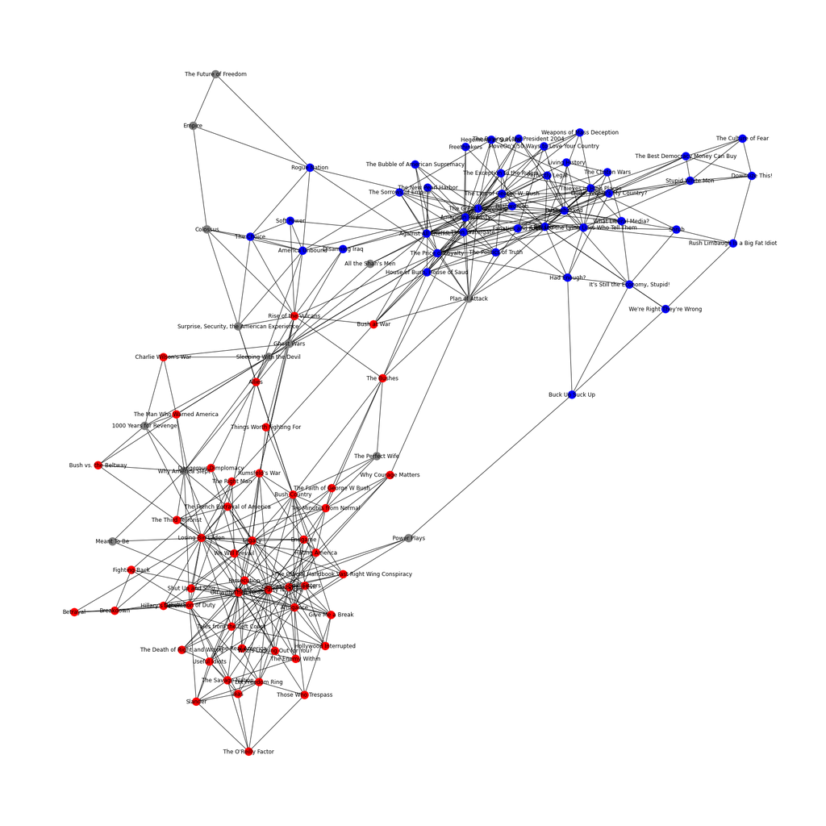

```python
G = nx.Graph()
color_map=[]
# This helps insure that no edge is left out
for n in range(0, len(politics_edges)):
    G.add_edges_from(
        [(politics_edges['Source'][n], politics_edges['Target'][n])])
#This colors the nodes in the node table accordingly
for n in G:
    if politics_nodes['political_ideology'][n] == 'neutral':
        color_map.append('gray')
    elif politics_nodes['political_ideology'][n] == 'conservative':
        color_map.append('red')
    else:
        color_map.append('blue')
# This helps relabel the nodes as the Labels from the nodes table
G = nx.relabel_nodes(G, politics_nodes['Label'])
#This helps the viewer read the graph more easily
plt.figure(figsize=(25,25))
nx.draw(G, node_color=color_map, with_labels=True)
plt.show()
```

Note: Red=Conservative, Gray=Neutral, Blue=Liberal

# 3.

My network has 105 nodes and 441 edges. It is not directed, but it is connected. The network also has conservative (red) nodes mostly always connected to other conservative nodes and vice versa (same thing but with blue nodes), with very few neutral nodes connected to each other (i.e they are either connected to a liberal and/or conservative node). This means that the network tells us that conservatives and liberals do not mix well together and are separated into two groups.

# 4.

Nodes

```python
for n in range(0,len(politics_nodes)):
    print("ID:", politics_nodes['Id'][n], "   Label:", politics_nodes['Label'][n], "   Political Side:", politics_nodes['political_ideology'][n])
```

```
ID: 0    Label: 1000 Years for Revenge    Political Side: neutral
ID: 1    Label: Bush vs. the Beltway    Political Side: conservative
ID: 2    Label: Charlie Wilson's War    Political Side: conservative
ID: 3    Label: Losing Bin Laden    Political Side: conservative
ID: 4    Label: Sleeping With the Devil    Political Side: neutral
ID: 5    Label: The Man Who Warned America    Political Side: conservative
ID: 6    Label: Why America Slept    Political Side: neutral
ID: 7    Label: Ghost Wars    Political Side: neutral
ID: 8    Label: A National Party No More    Political Side: conservative
ID: 9    Label: Bush Country    Political Side: conservative
ID: 10    Label: Dereliction of Duty    Political Side: conservative
ID: 11    Label: Legacy    Political Side: conservative
ID: 12    Label: Off with Their Heads    Political Side: conservative
ID: 13    Label: Persecution    Political Side: conservative
ID: 14    Label: Rumsfeld's War    Political Side: conservative
ID: 15    Label: Breakdown    Political Side: conservative
ID: 16    Label: Betrayal    Political Side: conservative
ID: 17    Label: Shut Up and Sing    Political Side: conservative
ID: 18    Label: Meant To Be    Political Side: neutral
ID: 19    Label: The Right Man    Political Side: conservative
ID: 20    Label: Ten Minutes from Normal    Political Side: conservative
ID: 21    Label: Hillary's Scheme    Political Side: conservative
ID: 22    Label: The French Betrayal of America    Political Side: conservative
ID: 23    Label: Tales from the Left Coast    Political Side: conservative
ID: 24    Label: Hating America    Political Side: conservative
ID: 25    Label: The Third Terrorist    Political Side: conservative
ID: 26    Label: Endgame    Political Side: conservative
ID: 27    Label: Spin Sisters    Political Side: conservative
ID: 28    Label: All the Shah's Men    Political Side: neutral
ID: 29    Label: Dangerous Dimplomacy    Political Side: conservative
ID: 30    Label: The Price of Loyalty    Political Side: liberal
ID: 31    Label: House of Bush, House of Saud    Political Side: liberal
ID: 32    Label: The Death of Right and Wrong    Political Side: conservative
ID: 33    Label: Useful Idiots    Political Side: conservative
ID: 34    Label: The O'Reilly Factor    Political Side: conservative
ID: 35    Label: Let Freedom Ring    Political Side: conservative
ID: 36    Label: Those Who Trespass    Political Side: conservative
ID: 37    Label: Bias    Political Side: conservative
ID: 38    Label: Slander    Political Side: conservative
ID: 39    Label: The Savage Nation    Political Side: conservative
```

[output cut: 50 more lines]

```
ID: 90    Label: Hegemony or Survival    Political Side: liberal
ID: 91    Label: The Exception to the Rulers    Political Side: liberal
ID: 92    Label: Freethinkers    Political Side: liberal
ID: 93    Label: Had Enough?    Political Side: liberal
ID: 94    Label: It's Still the Economy, Stupid!    Political Side: liberal
ID: 95    Label: We're Right They're Wrong    Political Side: liberal
ID: 96    Label: What Liberal Media?    Political Side: liberal
ID: 97    Label: The Clinton Wars    Political Side: liberal
ID: 98    Label: Weapons of Mass Deception    Political Side: liberal
ID: 99    Label: Dude, Where's My Country?    Political Side: liberal
ID: 100    Label: Thieves in High Places    Political Side: liberal
ID: 101    Label: Shrub    Political Side: liberal
ID: 102    Label: Buck Up Suck Up    Political Side: liberal
ID: 103    Label: The Future of Freedom    Political Side: neutral
ID: 104    Label: Empire    Political Side: neutral
```

Edges

```python
for n in range(0,100):
    print("Source:", politics_nodes['Label'][politics_edges['Source'][n]], "   Target:", politics_nodes['Label'][politics_edges['Target'][n]],"   Weight:", politics_edges['Weight'][n])
```

```
Source: Bush vs. the Beltway    Target: 1000 Years for Revenge    Weight: 1
Source: Charlie Wilson's War    Target: 1000 Years for Revenge    Weight: 1
Source: Losing Bin Laden    Target: 1000 Years for Revenge    Weight: 1
Source: Losing Bin Laden    Target: Bush vs. the Beltway    Weight: 1
Source: Sleeping With the Devil    Target: 1000 Years for Revenge    Weight: 1
Source: Sleeping With the Devil    Target: Charlie Wilson's War    Weight: 1
Source: The Man Who Warned America    Target: 1000 Years for Revenge    Weight: 1
Source: The Man Who Warned America    Target: Bush vs. the Beltway    Weight: 1
Source: The Man Who Warned America    Target: Charlie Wilson's War    Weight: 1
Source: The Man Who Warned America    Target: Losing Bin Laden    Weight: 1
Source: The Man Who Warned America    Target: Sleeping With the Devil    Weight: 1
Source: Why America Slept    Target: 1000 Years for Revenge    Weight: 1
Source: Why America Slept    Target: Bush vs. the Beltway    Weight: 1
Source: Why America Slept    Target: Sleeping With the Devil    Weight: 1
Source: Why America Slept    Target: The Man Who Warned America    Weight: 1
Source: Ghost Wars    Target: Charlie Wilson's War    Weight: 1
Source: Ghost Wars    Target: The Man Who Warned America    Weight: 1
Source: Ghost Wars    Target: Why America Slept    Weight: 1
Source: A National Party No More    Target: Losing Bin Laden    Weight: 1
Source: Bush Country    Target: Losing Bin Laden    Weight: 1
Source: Bush Country    Target: A National Party No More    Weight: 1
Source: Dereliction of Duty    Target: Losing Bin Laden    Weight: 1
Source: Dereliction of Duty    Target: Why America Slept    Weight: 1
Source: Dereliction of Duty    Target: A National Party No More    Weight: 1
Source: Legacy    Target: Losing Bin Laden    Weight: 1
Source: Legacy    Target: A National Party No More    Weight: 1
Source: Legacy    Target: Bush Country    Weight: 1
Source: Legacy    Target: Dereliction of Duty    Weight: 1
Source: Off with Their Heads    Target: Losing Bin Laden    Weight: 1
Source: Off with Their Heads    Target: Why America Slept    Weight: 1
Source: Off with Their Heads    Target: A National Party No More    Weight: 1
Source: Off with Their Heads    Target: Bush Country    Weight: 1
Source: Off with Their Heads    Target: Dereliction of Duty    Weight: 1
Source: Off with Their Heads    Target: Legacy    Weight: 1
Source: Persecution    Target: Losing Bin Laden    Weight: 1
Source: Persecution    Target: A National Party No More    Weight: 1
Source: Persecution    Target: Legacy    Weight: 1
Source: Persecution    Target: Off with Their Heads    Weight: 1
Source: Rumsfeld's War    Target: Losing Bin Laden    Weight: 1
Source: Rumsfeld's War    Target: A National Party No More    Weight: 1
```

[output cut: 45 more lines]

```
Source: Endgame    Target: A National Party No More    Weight: 1
Source: Endgame    Target: Legacy    Weight: 1
Source: Endgame    Target: Rumsfeld's War    Weight: 1
Source: Endgame    Target: Hating America    Weight: 1
Source: Spin Sisters    Target: Losing Bin Laden    Weight: 1
Source: Spin Sisters    Target: A National Party No More    Weight: 1
Source: Spin Sisters    Target: Bush Country    Weight: 1
Source: Spin Sisters    Target: Legacy    Weight: 1
Source: Spin Sisters    Target: Tales from the Left Coast    Weight: 1
Source: All the Shah's Men    Target: Sleeping With the Devil    Weight: 1
Source: Dangerous Dimplomacy    Target: Sleeping With the Devil    Weight: 1
Source: Dangerous Dimplomacy    Target: Why America Slept    Weight: 1
Source: Dangerous Dimplomacy    Target: Legacy    Weight: 1
Source: Dangerous Dimplomacy    Target: Persecution    Weight: 1
Source: The Price of Loyalty    Target: Sleeping With the Devil    Weight: 1
```

# 5.

```python
new_listNodes = []

new_listEdges = []

for n in range(0,len(politics_nodes)):
    new_listNodes.append(politics_nodes['Id'][n])
    new_listNodes.append(politics_nodes['Label'][n])
    new_listNodes.append(politics_nodes['political_ideology'][n])
for n in range(0,100):
    new_listEdges.append(politics_nodes['Label'][politics_edges['Source'][n]])
    new_listEdges.append(politics_nodes['Label'][politics_edges['Target'][n]])
    new_listEdges.append(politics_edges['Weight'][n])
print(new_listNodes,new_listEdges)
```

```
[0, '1000 Years for Revenge', 'neutral', 1, 'Bush vs. the Beltway', 'conservative', 2, "Charlie Wilson's War", 'conservative', 3, 'Losing Bin Laden', 'conservative', 4, 'Sleeping With the Devil', 'neutral', 5, 'The Man Who Warned America', 'conservative', 6, 'Why America Slept', 'neutral', 7, 'Ghost…
```

# 6.

```python
pd.DataFrame.from_dict(G.nodes(data = True))
```

|  | 0 | 1 |
| --- | --- | --- |
| 0 | Bush vs. the Beltway | {} |
| 1 | 1000 Years for Revenge | {} |
| 2 | Charlie Wilson's War | {} |
| 3 | Losing Bin Laden | {} |
| 4 | Sleeping With the Devil | {} |
| ... | ... | ... |
| 100 | Thieves in High Places | {} |
| 101 | Shrub | {} |
| 102 | Buck Up Suck Up | {} |
| 103 | The Future of Freedom | {} |
| 104 | Empire | {} |

105 rows × 2 columns

```python
pd.DataFrame.from_dict(G.edges(data = True))
```

|  | 0 | 1 | 2 |
| --- | --- | --- | --- |
| 0 | Bush vs. the Beltway | 1000 Years for Revenge | {} |
| 1 | Bush vs. the Beltway | Losing Bin Laden | {} |
| 2 | Bush vs. the Beltway | The Man Who Warned America | {} |
| 3 | Bush vs. the Beltway | Why America Slept | {} |
| 4 | 1000 Years for Revenge | Charlie Wilson's War | {} |
| ... | ... | ... | ... |
| 436 | What Liberal Media? | Thieves in High Places | {} |
| 437 | Weapons of Mass Deception | Thieves in High Places | {} |
| 438 | Dude, Where's My Country? | Thieves in High Places | {} |
| 439 | Thieves in High Places | Shrub | {} |
| 440 | The Future of Freedom | Empire | {} |

441 rows × 3 columns

I could not figure out how to show attributes for the nodes DataFrame, as It would not show the poltical ideology. As for the edges, It isn't nearly as bad because one can assume that all the edges have the same weight, which in this case it does. However, I really need to figure out how to do stuff like this in the future. As for why it would be more helpful to read a DataFrame instead of a NetworkX Graph, it is because the data itself is neatly organized into separate columns, each of which has a distinct attribute.

# 7.

Adjacency Matrix:

```python
A = nx.adjacency_matrix(G)
print(A.todense())
```

```
[[0 1 0 ... 0 0 0]
 [1 0 1 ... 0 0 0]
 [0 1 0 ... 0 0 0]
 ...
 [0 0 0 ... 0 0 0]
 [0 0 0 ... 0 0 1]
 [0 0 0 ... 0 1 0]]
```

GML File:

```python
M = nx.generate_gml(G)
print("\n".join(M))
```

```
graph [
  node [
    id 0
    label "Bush vs. the Beltway"
  ]
  node [
    id 1
    label "1000 Years for Revenge"
  ]
  node [
    id 2
    label "Charlie Wilson's War"
  ]
  node [
    id 3
    label "Losing Bin Laden"
  ]
  node [
    id 4
    label "Sleeping With the Devil"
  ]
  node [
    id 5
    label "The Man Who Warned America"
  ]
  node [
    id 6
    label "Why America Slept"
  ]
  node [
    id 7
    label "Ghost Wars"
  ]
  node [
    id 8
    label "A National Party No More"
  ]
  node [
    id 9
    label "Bush Country"
```

[output cut: 2131 more lines]

```
    target 100
  ]
  edge [
    source 99
    target 100
  ]
  edge [
    source 100
    target 101
  ]
  edge [
    source 103
    target 104
  ]
]
```

JSON:

```python
s1 = JSON.dumps(G, default=nx.node_link_data)
s1
```

```
'{"directed": false, "multigraph": false, "graph": {}, "nodes": [{"id": "Bush vs. the Beltway"}, {"id": "1000 Years for Revenge"}, {"id": "Charlie Wilson\'s War"}, {"id": "Losing Bin Laden"}, {"id": "Sleeping With the Devil"}, {"id": "The Man Who Warned America"}, {"id": "Why America Slept"}, {"id":…
```